# Part II - Ford GoBike System Data Analysis

## by Akintola Malik Olasubomi

## Investigation Overview

> I will be showing the Trips per day and period time. The peak times are mostly due to the rush hour.

> I will also show the days of the weeks and the number of rides taken per day. It is surprising that weekends have lesser number of rides but the rides are averagely longer.

> We shall then look at the Frequent user types, and their duration. We will then look ak these usertypes duration per day.

> **Rubric Tip**: The key insights in the slideshow must match those documented in the README.md summary.

## Most Common Trip Time and Period

Trips are most commonly taken in the morning and evening periods, with peaks at 8am and 5pm. These are rush hours for people going to and returning back from work respectively, hence the high amount of rides

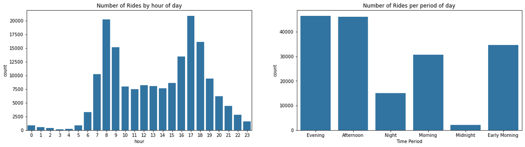

## Trips per day

More trips are taken during the weekdays than at weekends. Saturdays and Sundays have the lowest number of trips. People might prefer to take a bike ride to work during the weekdays and ride their personal vehicles at weekends. But the weekends rides are averagely longer than the weekdays ride. People tend to ride longer when it is for leisure

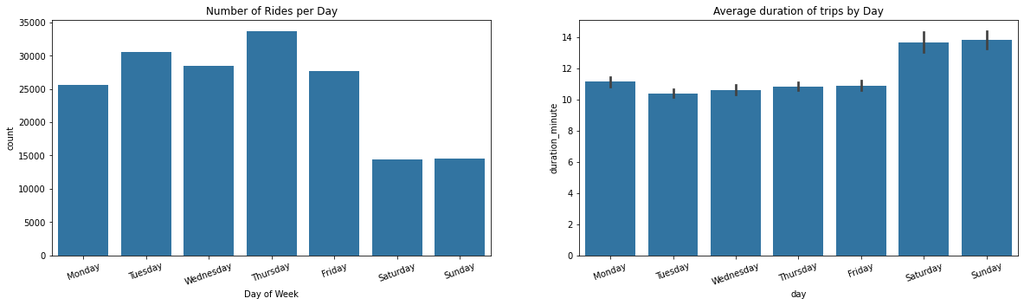

## Most Frequent Users And duration of use

Subscribers take a bike ride far more than customers do, but customers tend to ride it for a longer period of time on the average.

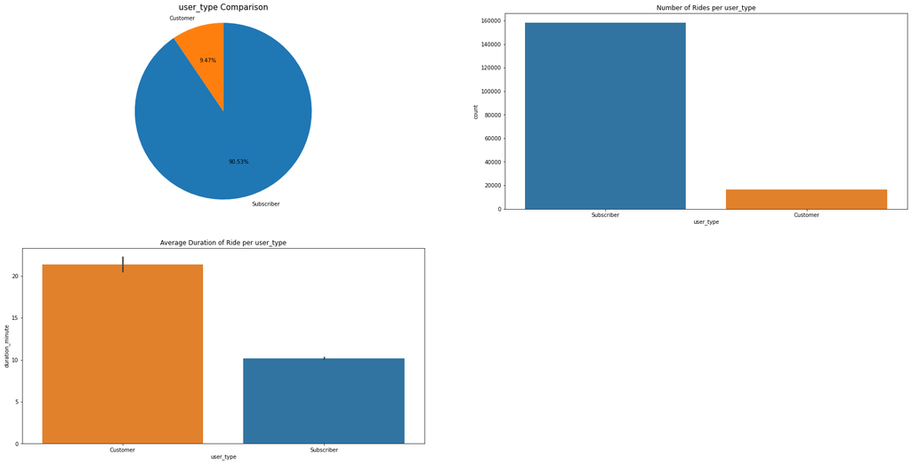

### Duration of ride per day and usertype

Both the Subscribers and Customers ride more on Saturdays and Sundays, telling us that the increase in duration of ride on these days is not exclusive to one party.

Subscribers most likelyhave a limit to the amount of time they can spend per ride. The time of ride for the Subscribers hardly varies from day to day and they might have to stick to a particular purpose of ride.

Customers on the other hand are at ease of time. They might not have time limit, and if they do, it won't be as less as the Subscribers'. Their time f ride varies from day to da, telling us that every one of them is able to ride at his own pleasure and dicretion of time.

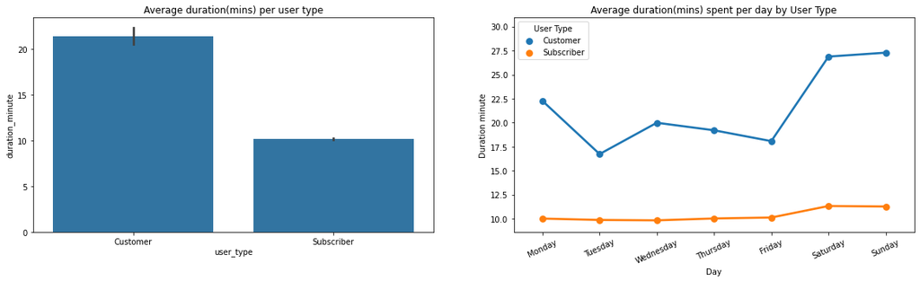